# Advanced Bioinformatics 2026 Assessment

m2503513

2026-03-24

# General R/Rstudio Assessment

#### Loading the libraries required throughout the General R/Rstudio Assessment.

```r
#Load the ggplot library
library(ggplot2)
```

## Task 1 Sum of the integers between 5 and 55

In task 1, the (5:55) creates a vector containing the integers between 5 and 55 and the sum() takes this vector and adds them together.

```r
#An expression that evaluates the sum of all integers between 5 and 55

sum(5:55)
```

```
## [1] 1530
```

## Task 2 Sum of all integers between 5 and n

In task 2, a function called sumfun is created to add the integers between 5 and n and then result the results. To execute the sumfun function for the variables 10, 20, 100, three variables called results_10, results_20, results_100 are created to store the results from sumfun(10), sumfun(20), sumfun(100). To present the results, results_10, results_20, results_100 are called.

```r
#Create a function that calculates the sum of all integers between 5 and n

sumfun <- function(n) {
  results <- sum(5:n)
  return(results)
}

#Execute the function for the variables n=10, n=20, n=100
results_10 <- sumfun(10)
results_20 <- sumfun(20)
results_100 <- sumfun(100)

#Present the results of the function
results_10
```

```
## [1] 45
```

```r
results_20
```

```
## [1] 200
```

```r
results_100
```

```
## [1] 5040
```

## Task 3 Fibonacci series

In task 3, a variable called fibonacci is created to hold the integers of the first 12 entries of the Fibonacci series. The first 2 entries of fibonacci are assigned the values 1 and 1 as these are the first 2 entries of the Fibonacci series. Next, a for loop is used to iterate over the remaining indices (3:12), assigning it the sum of the two previous entries.

```r
#Initialise a vector for the first 12 entries of the Fibonacci series
fibonacci <- numeric(12)
fibonacci[1] <- 1
fibonacci[2] <- 1

#Create a for loop to calculate the remaining 10 numbers
for (i in 3:12) {
  fibonacci[i] <- fibonacci[i-1] + fibonacci[i-2]
}

#Print the first 12 entries of the Fibonacci series
fibonacci
```

```
##  [1]   1   1   2   3   5   8  13  21  34  55  89 144
```

## Task 4 Visualisation of mpg by gear

In task 4, ggplot was used to visualise the relationship between mpg and gears in the mtcars data set. The gears variable was converted from a numerical variable into a factorial variable so it is treated as discrete and not continuous. gears was assigned to the x axis, mpg was assigned to the y axis and fill aesthetic was used to colour each box based on gears.

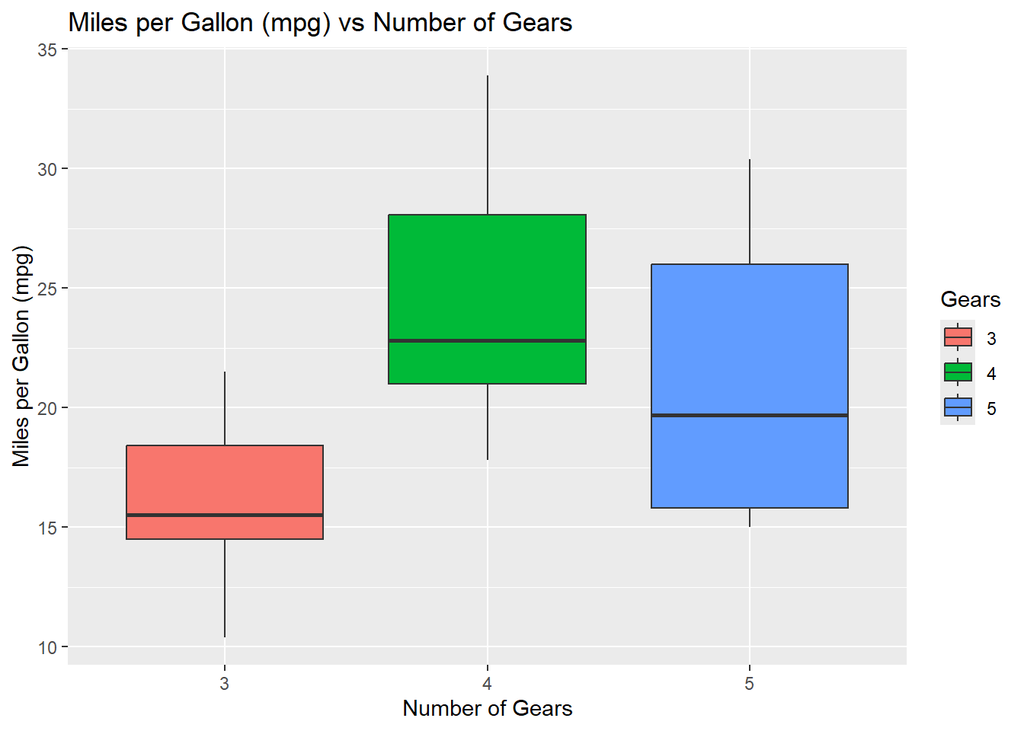

```r
#Generate a box plot of mpg as a function of gears
ggplot(mtcars, aes(x = factor(gear), y = mpg, fill = factor(gear))) +
  geom_boxplot() +
  labs(x = "Number of Gears", y = "Miles per Gallon (mpg)", fill = "Gears", title = "Miles per Gallon (mpg) vs Number of Gears")
```

## Task 5 Linear relationship between speed and distance

In task 5, a variable called cars_linear_model is created to store the results. The lm function was used to model the linear relationship between dist and speed, which is found cars data set. The summary function was used to determine the fitted sloped and intercept of the line, as well as their standard deviations. Next the help function was used to determine the units of distance (ft) and speed (mph).

#### What are the fitted slope and intercept of the line, and their standard errors?

Fitted slope: 3.9324, std. error 0.4155. Intercept: -17.5791, std. error 6.7584.

#### What are the units used for the variables in the dataset?

Speed: mph. Distance: ft.

```r
#Fit linear model between distance and speed
cars_linear_model <- lm(dist ~ speed, data = cars)

#Print the summary results
summary(cars_linear_model)
```

```
##
## Call:
## lm(formula = dist ~ speed, data = cars)
##
## Residuals:
##     Min      1Q  Median      3Q     Max
## -29.069  -9.525  -2.272   9.215  43.201
##
## Coefficients:
##             Estimate Std. Error t value Pr(>|t|)
## (Intercept) -17.5791     6.7584  -2.601   0.0123 *
## speed         3.9324     0.4155   9.464 1.49e-12 ***
## ---
## Signif. codes:  0 '***' 0.001 '**' 0.01 '*' 0.05 '.' 0.1 ' ' 1
##
## Residual standard error: 15.38 on 48 degrees of freedom
## Multiple R-squared:  0.6511, Adjusted R-squared:  0.6438
## F-statistic: 89.57 on 1 and 48 DF,  p-value: 1.49e-12
```

```r
#Help about the cars data set
help("cars")
```

```
## starting httpd help server ... done
```

## Task 6 Visualisation of speed (mph) and distance

In task 6, ggplot was used to visualise the linear relationship between speed (mph) and distance in the cars data set. The intercept_value and fitted_slope_value variables were created to store the respective coefficients in the cars_linear_model variable created in task 5. The coef function was used to determine the coefficients. speed was assigned to the x axis and dist was assigned to the y axis. geom_point plotted the points, geom_abline fitted the line of best fit based on intercept_value and fitted_slope_value.

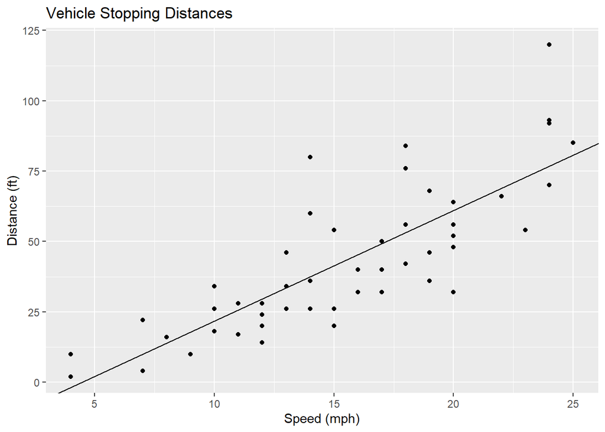

```r
#Extract values from cars_linear_model
intercept_value <- coef(cars_linear_model)[1]
fitted_slope_value <- coef(cars_linear_model)[2]

#Generate a linear plot of speed and distance
ggplot(cars, aes(x = speed, y = dist)) +
  geom_point() +
  geom_abline(intercept = intercept_value, slope = fitted_slope_value) +
  labs(x = "Speed (mph)", y = "Distance (ft)", title = "Vehicle Stopping Distances")
```

## Task 7 Calculation of average reaction time & visualisation of speed (fps) and distance

In task 7, speed was converted from mph to ft per seconds (fps) to ensure speed and distance are using equivalent units. A variable called reaction_linear_model is used to store the results. The lm function was used to model the linear relationship between dist and the sum of speed_fps and square of speed_fps. This is because the total distance is the sum of the reaction and braking distance. The -1 forces the lm function to intercept at 0,0. This is because when speed is 0, distance is 0. The summary function was used to visualise the speed_fps coefficient. The reaction_time variable was created to store the coefficient of speed_fps.

```r
#Convert speed from to ft per second.
cars$speed_fps <- cars$speed * 1.467

#Fit linear model between
reaction_linear_model <- lm(dist ~ speed_fps + I(speed_fps^2) -1, data = cars)

#Print the summary results
summary(reaction_linear_model)
```

```
##
## Call:
## lm(formula = dist ~ speed_fps + I(speed_fps^2) - 1, data = cars)
##
## Residuals:
##     Min      1Q  Median      3Q     Max
## -28.836  -9.071  -3.152   4.570  44.986
##
## Coefficients:
##                Estimate Std. Error t value Pr(>|t|)
## speed_fps       0.84460    0.38171   2.213  0.03171 *
## I(speed_fps^2)  0.04188    0.01366   3.067  0.00355 **
## ---
## Signif. codes:  0 '***' 0.001 '**' 0.01 '*' 0.05 '.' 0.1 ' ' 1
##
## Residual standard error: 15.02 on 48 degrees of freedom
## Multiple R-squared:  0.9133, Adjusted R-squared:  0.9097
## F-statistic: 252.8 on 2 and 48 DF,  p-value: < 2.2e-16
```

```r
#Extract reaction time from reaction_linear_model
reaction_time <- coef(reaction_linear_model)[1]
reaction_time
```

```
## speed_fps
## 0.8446012
```

In the continuation of task 7, ggplot was used to visualise the linear relationship between speed (fps) and distance. speed_fps was assigned the x axis and dist was assigned the y axis. geom_point plotted the points. geom_smooth fitted a curved line. It used a linear model (method = lm), and the formula y ~ x + I(x^2) -1 as explained above.

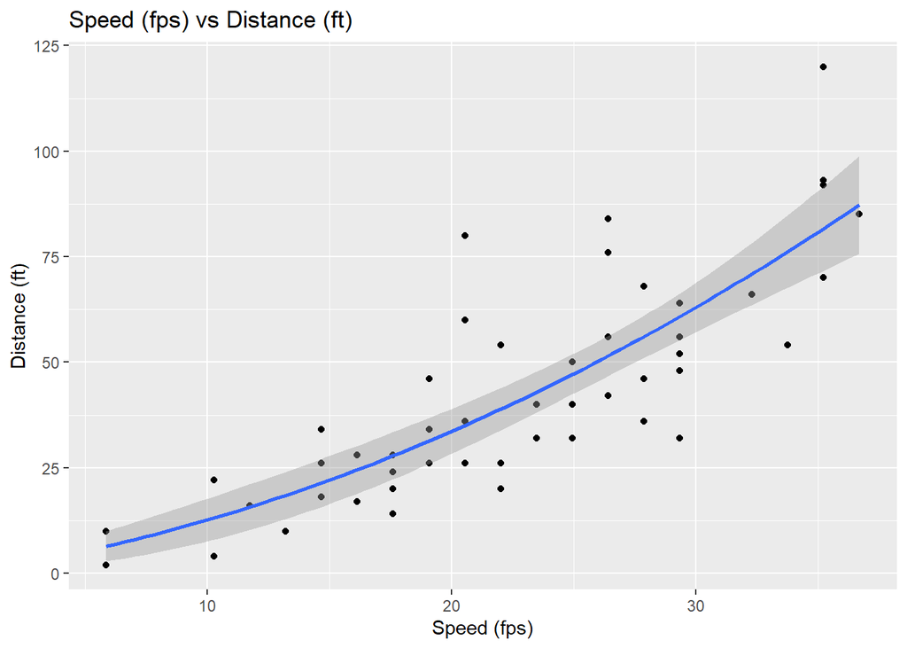

```r
#Generate a linear plot of speed_fps and distance
ggplot(cars, aes(x = speed_fps, y = dist)) +
  geom_point() +
  geom_smooth(method = "lm", formula = y ~ x + I(x^2) -1) +
  labs(x = "Speed (fps)", y = "Distance (ft)", title = "Speed (fps) vs Distance (ft)")
```

# RNA-seq Assessment

The data must be downloaded and extracted.

#### Loading the libraries required throughout the RNA-seq Assessment.

```r
suppressPackageStartupMessages({
  library(DESeq2)
  library("pheatmap")
  library(ggplot2)
  library("RColorBrewer")
})
```

## Task 8 Read in count data and sample description

In task 8, the read.csv function was used to extract the data from exercise1_counts.csv and stored it in the variable all_counts. The read.table function was used to extract the data from exercise1_sample_description.info and stored it in the variable sam_descript. The head, dim and class functions were used to explore the data in all_counts and sam_descript.

```r
#Read in count data
all_counts <- read.csv(file = "C:/Users/katem/Downloads/LMS_RNAseq_short-master-2023-final/LMS_RNAseq_short-master-2023-final/course/exercises/data/exercise1_counts.csv", header = T, row.name = 1)
head(all_counts)
```

```
##           control_FFa1.bam control_FFa2.bam control_FFa3.bam mutant_KOa1.bam
## 497097                  16               16                0              21
## 100503874               20                0                0              64
## 100038431                0                0                2               0
## 19888                   11                0               10             113
## 20671                   14               16                0              40
## 27395                  465              193              596             436
##           mutant_KOa2.bam mutant_KOa3.bam mutant_KOb1.bam mutant_KOb2.bam
## 497097                 16              27              20               0
## 100503874               0               4               5               0
## 100038431               0               8               0               0
## 19888                   0              26              14               6
## 20671                   8              33              33              12
## 27395                 686             572            1378            1901
##           mutant_KOb3.bam
## 497097                  2
## 100503874               2
## 100038431               0
## 19888                  16
## 20671                  24
## 27395                1553
```

```r
dim(all_counts)
```

```
## [1] 26301     9
```

```r
class(all_counts)
```

```
## [1] "data.frame"
```

```r
#Read in sample description
sam_descript <- read.table(file = "C:/Users/katem/Downloads/LMS_RNAseq_short-master-2023-final/LMS_RNAseq_short-master-2023-final/course/exercises/data/exercise1_sample_description.info", sep = "\t", header = TRUE)
head(sam_descript)
```

```
##              filename sample condition batch
## 1    control_FFa1.bam   FFa1       FFa     a
## 2    control_FFa2.bam   FFa2       FFa     b
## 3    control_FFa3.bam   FFa3       FFa     c
## 4 TMC_mutant_KOa1.bam   KOa1       KOa     a
## 5 TMC_mutant_KOa2.bam   KOa2       KOa     b
## 6 TMC_mutant_KOa3.bam   KOa3       KOa     c
```

```r
dim(sam_descript)
```

```
## [1] 9 4
```

```r
class(sam_descript)
```

```
## [1] "data.frame"
```

## Task 9 Create col_data and check dimensions

```r
#Create col_data from sam_descript
col_data <- data.frame(sample = sam_descript$sample, condition = sam_descript$condition, batch = sam_descript$batch)
head(col_data)
```

```
##   sample condition batch
## 1   FFa1       FFa     a
## 2   FFa2       FFa     b
## 3   FFa3       FFa     c
## 4   KOa1       KOa     a
## 5   KOa2       KOa     b
## 6   KOa3       KOa     c
```

```r
#Store data as factors
col_data$sample <- as.factor(col_data$sample)
col_data$condition <- as.factor(col_data$condition)
col_data$batch <- as.factor(col_data$batch)

#Check the dimensions
all(colnames(all_counts) == col_data$name)
```

```
## [1] TRUE
```

## Task 10 Construct DESeqDataSet object

In task 10, the DESeqDataSetFromMatrix function is used to merge all the data which is stored in the variable dds.

```r
#Construct DESeqDataSet object using count data and sample description
dds <- DESeqDataSetFromMatrix(countData = all_counts, colData = col_data, design = ~condition)
dds
```

```
## class: DESeqDataSet
## dim: 26301 9
## metadata(1): version
## assays(1): counts
## rownames(26301): 497097 100503874 ... 100040384 100040400
## rowData names(0):
## colnames(9): control_FFa1.bam control_FFa2.bam ... mutant_KOb2.bam
##   mutant_KOb3.bam
## colData names(3): sample condition batch
```

## Task 11 Perform rlog and VST transformation on the data

In task 11, the rlog and varianceStabilizingTransformation functions are used to transform the data in the dds variable. This normalises the data so it can be statistically analysed. The data is stored in the rld and vsd variables respectively. Next the assay function is used on the rld and vsd to get each into a count format. The data is stored in the rld_counts and vsd_counts variables respectively.

```r
#rlog transformation
rld <- rlog(dds)

# Get rld in count format
rld_counts <- assay(rld)

#VST transformation
vsd <- varianceStabilizingTransformation(dds)

# Get vst in count format
vsd_counts <- assay(vsd)
```

## Task 12 Visualisation of top 40 highly expressed genes in a heatmap

In task 12, the DESeq function was used to normalise the data in dds and updates the dds variable to store it. The counts function was used to get the normalised counts from the dds variable and stored the data in the dds_counts variable. The order function was used to sort the rows in dds_counts in descending order according to the mean. The [1:40] selects the top 40 highly expressed genes and this data is stored in the select variable. The head function is used to visualise the dds_count and select variables. The pheatmap function is used the generate a heatmap of the rld and vsd transformed data.

```r
# Apply DESeq normalisation
dds <- DESeq(dds)
#Get dds normalised counts
dds_counts <- counts(dds, normalized = TRUE)
head(dds_counts)
```

```
##           control_FFa1.bam control_FFa2.bam control_FFa3.bam mutant_KOa1.bam
## 497097            19.13143         30.06784         0.000000        24.18065
## 100503874         23.91429          0.00000         0.000000        73.69341
## 100038431          0.00000          0.00000         1.993454         0.00000
## 19888             13.15286          0.00000         9.967268       130.11493
## 20671             16.74000         30.06784         0.000000        46.05838
## 27395            556.00730        362.69327       594.049156       502.03639
##           mutant_KOa2.bam mutant_KOa3.bam mutant_KOb1.bam mutant_KOb2.bam
## 497097           18.61164       30.191405       12.646378        0.000000
## 100503874         0.00000        4.472801        3.161594        0.000000
## 100038431         0.00000        8.945602        0.000000        0.000000
## 19888             0.00000       29.073205        8.852464        3.354392
## 20671             9.30582       36.900606       20.866523        6.708784
## 27395           797.97410      639.610508      871.335429     1062.783210
##           mutant_KOb3.bam
## 497097           1.473775
## 100503874        1.473775
## 100038431        0.000000
## 19888           11.790200
## 20671           17.685300
## 27395         1144.386319
```

```r
#Normalised counts for top 40 highly expressed genes
select <- order(rowMeans(dds_counts), decreasing = TRUE)[1:40]
head(select)
```

```
## [1] 21373 10174 24719 21374 24718  2808
```

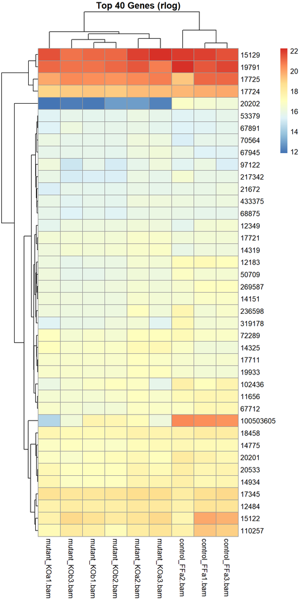

```r
#Generate a heatmap
pheatmap(assay(rld)[select, ], main = "Top 40 Genes (rlog)")
```

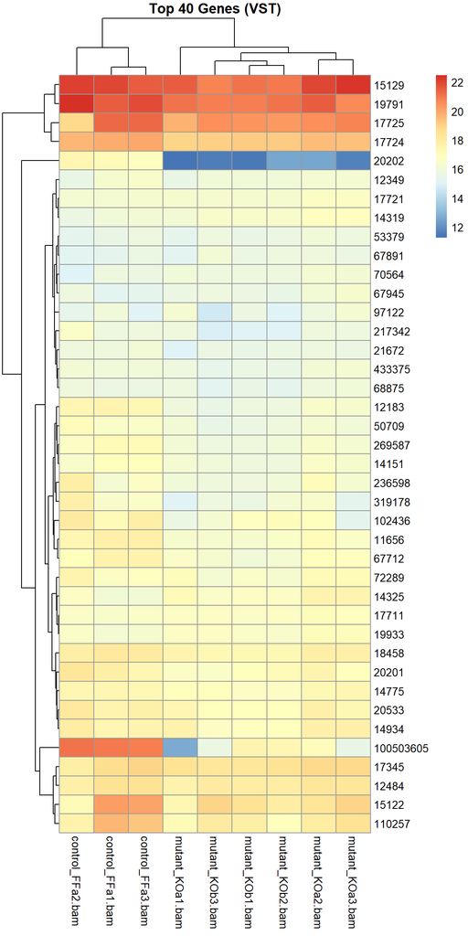

```r
pheatmap(assay(vsd)[select, ], main = "Top 40 Genes (VST)")
```

## Task 13 Generate a standard distance matrix (SDM) to see the clustering of count data

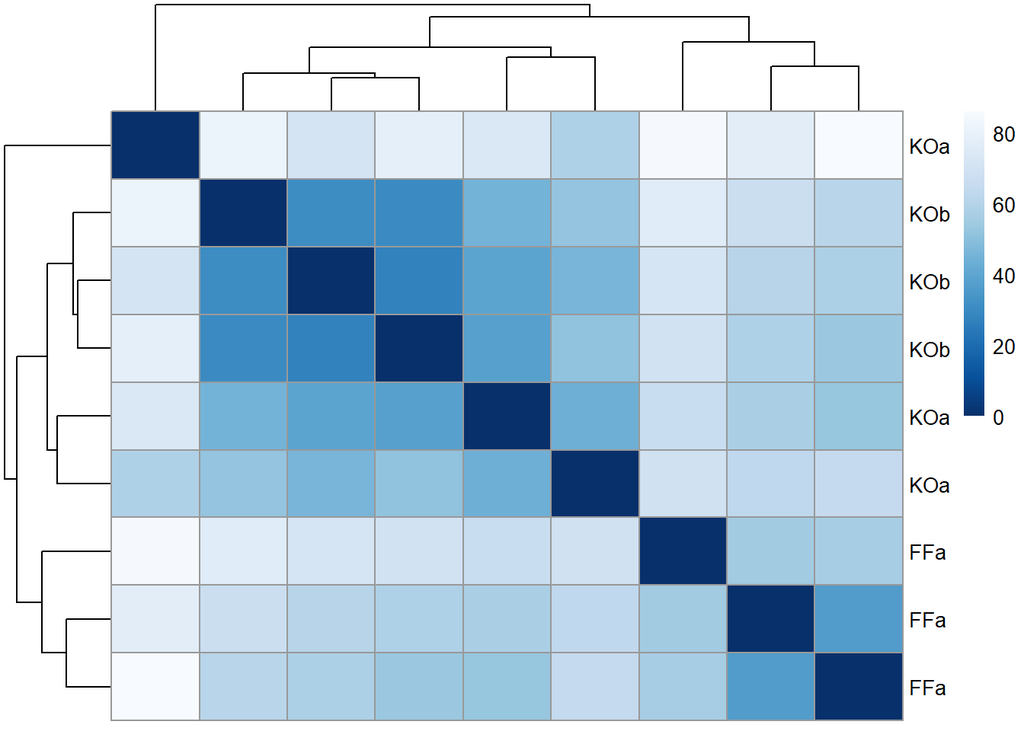

```r
# Calculate SDM from rlog transformed data
sample_dist <- dist(t(assay(rld)))

# Get SDM in matrix form
sdm <- as.matrix(sample_dist)

# Addition of row names for a clear plot
rownames(sdm) <- rld$condition
colnames(sdm) <- NULL

# Addition of colours
colours <- colorRampPalette(rev(brewer.pal(9, "Blues")))(255)

# Generate heatmap
pheatmap(sdm, clustering_distance_rows = sample_dist, clustering_distance_cols = sample_dist, col = colours)
```

## Task 14 Perform the Principal Component Analysis (PCA) using rlog method and find out the % significance values of first two principal components

In task 14, the plotPCA fucntion is used to perform PCA on the rlog transformed data, which is grouped and coloured based on condition.

```r
#PCA using rlog transformed data
pca_rld <- plotPCA(rld, intgroup = "condition")
```

```
## using ntop=500 top features by variance
```

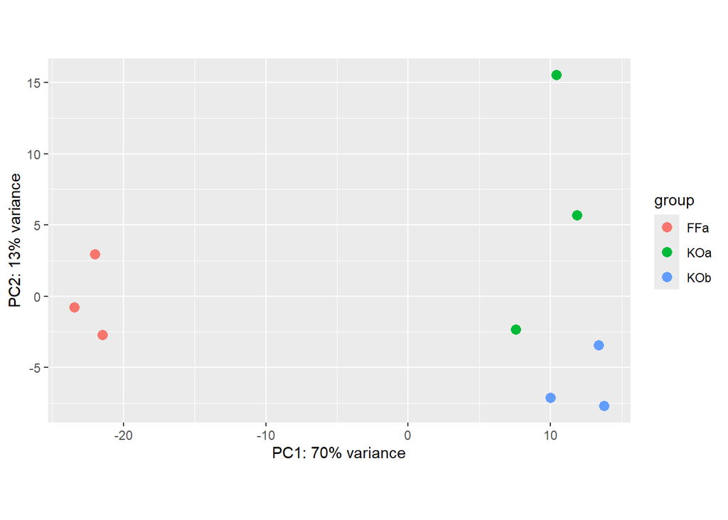

```r
pca_rld
```

## Task 15 Perform the Principal Component Analysis (PCA) using VST method. Compare the plot with the ones obtained using the rlog method

In task 15, the plotPCA function is used to perform PCA on the VST transformed data, which is grouped and coloured based on condition. The PCA plot generated using the rlog method showed PC1 explained 70% of the variance and PC2 explained 13% of the variance. This is similar to the PCA plot generated using the VST method; PC1 explained 69% of the variance and PC2 explained 14% of the variance. Both methods suggest PC1 explains a greater proportion of the variance compared to PC2.

```r
#PCA using VST transformed data
pca_vsd <- plotPCA(vsd, intgroup = "condition")
```

```
## using ntop=500 top features by variance
```

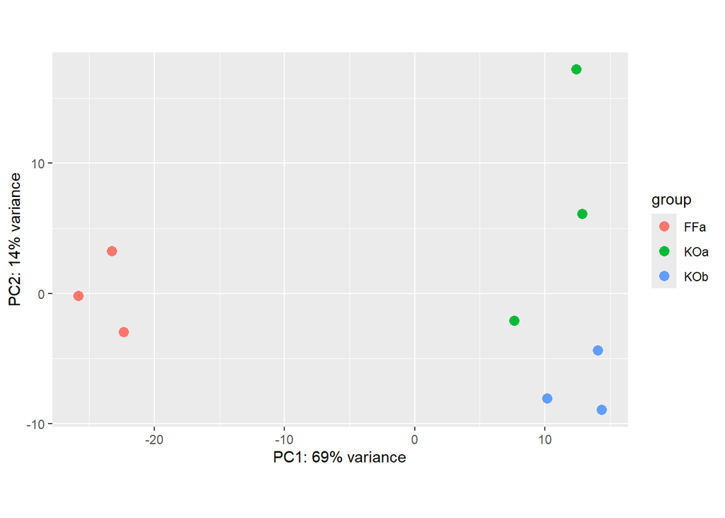

```r
pca_vsd
```